# Predicting MLB Team Wins Per Season

Test out several machine learning models from sklearn to predict the number of games that a Major-League Baseball team won that season, based on the teams statistics and other variables from that season.

Build a model using historic data from previous seasons to forecast the upcoming one.

Given the time series nature of the data, you could generate indicators such as average wins per year over the previous five years, and other such factors, to make a highly accurate model. That is outside the scope, however and you will treat each row as independent.

Each row of our data will consist of a single team for a specific year.

## Steps of Using Scikit-Learn to Analyze Sports Data.

- Imported the data from an SQLite database and cleaned it up.
- Explored aspects of the data visually
- Engineered several new features
- Create a K-means clustering model, a couple different Linear Regression models, and how to test your predictions with the mean absolute error metric.

# Import and Preprocess Data

- querying a sqlite database using the sqlite3 package and converting to a DataFrame with pandas.
- This data will be filtered to only include currently active modern teams and only years where the team played 150 or more games.
  - First, download the file “lahman2016.sqlite” (here)
  - Then, load Pandas, pd is the common alias for Pandas.
  - Lastly, load sqlite3 and connect to the database

```python
# import `pandas` and `sqlite3`
import pandas as pd
import sqlite3
```

```python
# Connecting to SQLite Database downloaded in the computer
conn = sqlite3.connect('/Users/libolin/Downloads/lahman2016.sqlite')
```

## Write a query to fetch the results.

```python
# Querying Database for all seasons where a team played 150 or more games and is still active today.
query = '''select * from Teams
inner join TeamsFranchises
on Teams.franchID == TeamsFranchises.franchID
where Teams.G >= 150 and TeamsFranchises.active == 'Y';
'''

# Creating dataframe from query.
Teams = conn.execute(query).fetchall()
```

```python
#Use pandas, convert the results to a DataFrame and print the first 5 rows using the head() method
# Convert `Teams` to DataFrame
teams_df = pd.DataFrame(Teams)

# Print out first 5 rows
print(teams_df.head())
teams_df.shape
# There are 52 columns and 2287 observations
```

```
     0   1    2    3     4   5    6     7   8   9   ...        42   43   44  \
0  1961  AL  LAA  ANA  None   8  162  82.0  70  91  ...    603510  111  112
1  1962  AL  LAA  ANA  None   3  162  81.0  86  76  ...   1144063   97   97
2  1963  AL  LAA  ANA  None   9  161  81.0  70  91  ...    821015   94   94
3  1964  AL  LAA  ANA  None   5  162  81.0  82  80  ...    760439   90   90
4  1965  AL  CAL  ANA  None   7  162  80.0  75  87  ...    566727   97   98

    45   46   47   48                             49  50    51
0  LAA  LAA  LAA  ANA  Los Angeles Angels of Anaheim   Y  None
1  LAA  LAA  LAA  ANA  Los Angeles Angels of Anaheim   Y  None
2  LAA  LAA  LAA  ANA  Los Angeles Angels of Anaheim   Y  None
3  LAA  LAA  LAA  ANA  Los Angeles Angels of Anaheim   Y  None
4  CAL  CAL  CAL  ANA  Los Angeles Angels of Anaheim   Y  None

[5 rows x 52 columns]
```

```
(2287, 52)
```

## Clean and Prepare The Data

- The DataFrame doesn’t have column headers. Add headers by passing a list of the headers to the columns attribute from pandas.

yearID - Year, teamID - Team, franchID - Franchise (links to TeamsFranchise table), G - Games played, W - Wins, LgWin - League Champion(Y or N) , WSWin - World Series Winner (Y or N) , R - Runs scored , AB - At bats , H - Hits by batters , HR - Homeruns by batters , BB - Walks by batters , SO - Strikeouts by batters , SB - Stolen bases , CS - Caught stealing , HBP - Batters hit by pitch , SF - Sacrifice flies , RA - Opponents runs scored , ER - Earned runs allowed , ERA - Earned run average , CG - Complete games , SHO - Shutouts , SV - Saves , IPOuts - Outs Pitched (innings pitched x 3) , HA - Hits allowed , HRA - Homeruns allowed , BBA - Walks allowed , SOA - Strikeouts by pitchers , E - Errors , DP - Double Plays , FP - Fielding percentage , name - Team’s full name

- Prior to assessing the data quality, first eliminate the columns that aren’t necessary or are derived from the target column/ Dependent Variable: Wins.

```python
# Adding column names to dataframe
cols = ['yearID','lgID','teamID','franchID','divID','Rank','G','Ghome','W','L','DivWin','WCWin','LgWin','WSWin',
        'R','AB','H','2B','3B','HR','BB','SO','SB','CS','HBP','SF','RA','ER','ERA','CG','SHO','SV','IPouts','HA','HRA',
        'BBA','SOA','E','DP','FP','name','park','attendance','BPF','PPF','teamIDBR',
        'teamIDlahman45','teamIDretro','franchID','franchName','active','NAassoc']
teams_df.columns = cols
# Print the length of `teams_df`
print(len(teams_df))
```

```
2287
```

```python
#Dropping your unnecesary column variables.
drop_cols = ['lgID','franchID','divID','Rank','Ghome','L','DivWin','WCWin','LgWin','WSWin','SF','name','park','attendance','BPF','PPF','teamIDBR','teamIDlahman45','teamIDretro','franchID','franchName','active','NAassoc']
df = teams_df.drop(drop_cols, axis=1)
print(df.head())
print(df.shape)
#There are 29 columns/ features left
```

```
   yearID teamID    G   W    R    AB     H   2B  3B   HR  ...    SHO  SV  \
0    1961    LAA  162  70  744  5424  1331  218  22  189  ...      5  34
1    1962    LAA  162  86  718  5499  1377  232  35  137  ...     15  47
2    1963    LAA  161  70  597  5506  1378  208  38   95  ...     13  31
3    1964    LAA  162  82  544  5362  1297  186  27  102  ...     28  41
4    1965    CAL  162  75  527  5354  1279  200  36   92  ...     14  33

   IPouts    HA  HRA  BBA  SOA    E     DP     FP
0    4314  1391  180  713  973  192  154.0  0.969
1    4398  1412  118  616  858  175  153.0  0.972
2    4365  1317  120  578  889  163  155.0  0.974
3    4350  1273  100  530  965  138  168.0  0.978
4    4323  1259   91  563  847  123  149.0  0.981

[5 rows x 29 columns]
(2287, 29)
```

```python
#eliminate null values.
#it might be a better idea to first display the count of null values for each column.
print(df.isnull().sum(axis=0).tolist())

#Two of the columns have a relatively small amount of null values:110 null values in the SO (Strike Outs) column and 22 in the DP (Double Play) column.
#Two of the columns have a relatively large amount of them: 419 null values in the CS (Caught Stealing) column and 1777 in the HBP (Hit by Pitch) column.
```

```
[0, 0, 0, 0, 0, 0, 0, 0, 0, 0, 0, 110, 0, 419, 1777, 0, 0, 0, 0, 0, 0, 0, 0, 0, 0, 0, 0, 22, 0]
```

SO:2177, CS:1868, HBP:510, DP:2265,

- If you eliminate the rows where the columns have a small number of null values, you’re losing a little over five percent of our data.
- The goal is to predict wins, runs scored and runs allowed are highly correlated with the target: Wins.
- Considering the knowledge of baseball, fill missing value in the rows where the columns have a small number of null values and delete columns with a large amount of missing values

```python
# Eliminating columns CS and HBP since there are too many missing values
df = df.drop(['CS','HBP'], axis=1)
# Filling null values
df['SO'] = df['SO'].fillna(df['SO'].median())
df['DP'] = df['DP'].fillna(df['DP'].median())
```

```python
# Print out null values of all columns of `df`
print(df.isnull().sum(axis=0).tolist())
print(df.shape)
```

```
[0, 0, 0, 0, 0, 0, 0, 0, 0, 0, 0, 0, 0, 0, 0, 0, 0, 0, 0, 0, 0, 0, 0, 0, 0, 0, 0]
(2287, 27)
```

## Exploring and Visualizing The Data

matplotlib is an excellent library for data visualization in Python  
Import matplotlib.pyplot and rename it as plt. Since I'm working with a Jupyter notebook, I can use the %matplotlib inline.

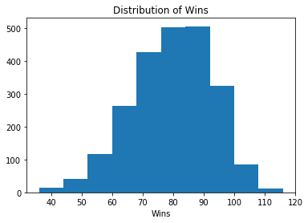

```
79.2304328815
```

```python
# import the pyplot module from matplotlib
import matplotlib.pyplot as plt

# matplotlib plots inline
%matplotlib inline

# Plotting distribution of the target/ dependent variable: Wins
plt.hist(df['W'])
plt.xlabel('Wins')
plt.title('Distribution of Wins')
plt.show()

# the average wins (W) per year
print(df['W'].mean())
```

It can be useful to create bins for the target column while exploring the data, but I need to make sure not to include any feature that you generate from your target column when training the model.

Including a column of labels generated from the target column in the training set would be like giving the model the answers to the test.

- Create a function called assign_win_bins which will take in an integer value (wins) and return an integer of 1-5 depending on the input value.

```python
# Creating bins for the win column
def assign_win_bins(W):
    if W < 50:
        return 1
    if W >= 50 and W <= 69:
        return 2
    if W >= 70 and W <= 89:
        return 3
    if W >= 90 and W <= 109:
        return 4
    if W >= 110:
        return 5
df['win_bins'] = df['W'].apply(assign_win_bins)
```

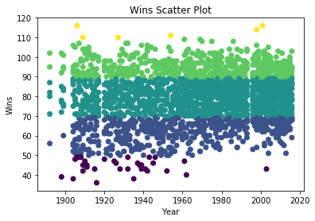

```python
# Plotting scatter graph of Year vs. Wins
plt.scatter(df['yearID'], df['W'], c=df['win_bins'])
plt.title('Wins Scatter Plot')
plt.xlabel('Year')
plt.ylabel('Wins')

plt.show()
```

- **There are very few seasons from before 1900 and the game was much different back then.** Because of that, it makes sense to eliminate those rows from the data set.

```python
# Filter for rows where 'yearID' is greater than 1900
df = df[df['yearID'] > 1900]
```

When dealing with continuous data and creating linear models, integer values such as a year can cause issues. It is unlikely that the number 1950 will have the same relationship to the rest of the data that the model will infer. **Avoid these issues by creating new variables that label the data based on the yearID value.**

**Make a graph below that indicates how much scoring there was for each year**.

- start by creating dictionaries runs_per_year and games_per_year. Loop through the dataframe using the **iterrows() method**.  
  Populate the runs_per_year dictionary with years as keys and how many runs were scored that year as the value. Populate the games_per_year dictionary with years as keys and how many games were played that year as the value.
- Next, create a dictionary called mlb_runs_per_game. Iterate through the games_per_year dictionary with the **items() method**.  
  Populate the mlb_runs_per_game dictionary with years as keys and the number of runs scored per game, league wide, as the value.
- Finally, create your plot from the mlb_runs_per_game dictionary by putting the years on the x-axis and runs per game on the y-axis.

```python
print(df['yearID'].head(),df['R'].head(),df['G'].head())
print(row['yearID'])
print(row['R'])
print(row['G'])
```

[output not shown]

```python
# Create runs per year and games per year dictionaries
runs_per_year = {}
games_per_year = {}

for i, row in df.iterrows():
    year = row['yearID']
    runs = row['R']
    games = row['G']
    if year in runs_per_year:
        runs_per_year[year] = runs_per_year[year] + runs
        games_per_year[year] = games_per_year[year] + games
    else:
        runs_per_year[year] = runs
        games_per_year[year] = games

print(runs_per_year)
print(games_per_year)
```

```
{1904: 9307, 1905: 9640, 1906: 8322, 1907: 8186, 1908: 8423, 1909: 8805, 1910: 9580, 1911: 11164, 1912: 11154, 1913: 9964, 1914: 9408, 1915: 9444, 1916: 8889, 1917: 8948, 1920: 10762, 1921: 11935, 1922: 12059, 1923: 11874, 1924: 11722, 1925: 12596, 1926: 11443, 1927: 11745, 1928: 11645, 1929: 12747,…
{1904: 2498, 1905: 2474, 1906: 2307, 1907: 2317, 1908: 2488, 1909: 2482, 1910: 2498, 1911: 2474, 1912: 2464, 1913: 2468, 1914: 2512, 1915: 2490, 1916: 2494, 1917: 2494, 1920: 2468, 1921: 2458, 1922: 2476, 1923: 2466, 1924: 2462, 1925: 2456, 1926: 2468, 1927: 2472, 1928: 2462, 1929: 2458, 1930: 2468,…
```

```python
# Create MLB runs per game (per year) dictionary
mlb_runs_per_game = {}
for k, v in games_per_year.items():
    year = k
    games = v
    runs = runs_per_year[year]
    mlb_runs_per_game[year] = runs / games

print(mlb_runs_per_game)
```

```
{1904: 3, 1905: 3, 1906: 3, 1907: 3, 1908: 3, 1909: 3, 1910: 3, 1911: 4, 1912: 4, 1913: 4, 1914: 3, 1915: 3, 1916: 3, 1917: 3, 1920: 4, 1921: 4, 1922: 4, 1923: 4, 1924: 4, 1925: 5, 1926: 4, 1927: 4, 1928: 4, 1929: 5, 1930: 5, 1931: 4, 1932: 4, 1933: 4, 1934: 4, 1935: 4, 1936: 5, 1937: 4, 1938: 4, 19…
```

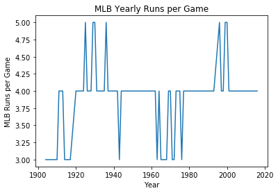

```python
# Create lists from mlb_runs_per_game dictionary
lists = sorted(mlb_runs_per_game.items())
x, y = zip(*lists)

# Create line plot of Year vs. MLB runs per Game
plt.plot(x, y)
plt.title('MLB Yearly Runs per Game')
plt.xlabel('Year')
plt.ylabel('MLB Runs per Game')

plt.show()

## the plot below can help have a better idea of scoring trends
```

## Adding Various New Features

Create new variables that indicate a specific era that each row of data falls in based on the yearID.

- Will create dummy columns; a new column for each era.
- Use the get_dummies() method for this.

```python
# Creating "year_label" column, which will give your algorithm information about how certain years are related
# (Dead ball eras, Live ball/Steroid Eras)

def assign_label(year):
    if year < 1920:
        return 1
    elif year >= 1920 and year <= 1941:
        return 2
    elif year >= 1942 and year <= 1945:
        return 3
    elif year >= 1946 and year <= 1962:
        return 4
    elif year >= 1963 and year <= 1976:
        return 5
    elif year >= 1977 and year <= 1992:
        return 6
    elif year >= 1993 and year <= 2009:
        return 7
    elif year >= 2010:
        return 8
```

```python
# Add 'year_label' column to 'df'
df['year_label'] = df['yearID'].apply(assign_label)

# Create dummy variables from new column 'year_label'
dummy_df = pd.get_dummies(df['year_label'], prefix='era')

# Concatenate 'df' and 'dummy_df'
df = pd.concat([df, dummy_df], axis=1)

print(df.head())
```

```
   yearID teamID    G   W    R    AB     H   2B  3B   HR  ...    win_bins  \
0    1961    LAA  162  70  744  5424  1331  218  22  189  ...           3
1    1962    LAA  162  86  718  5499  1377  232  35  137  ...           3
2    1963    LAA  161  70  597  5506  1378  208  38   95  ...           3
3    1964    LAA  162  82  544  5362  1297  186  27  102  ...           3
4    1965    CAL  162  75  527  5354  1279  200  36   92  ...           3

   year_label  era_1  era_2  era_3  era_4  era_5  era_6  era_7  era_8
0           4      0      0      0      1      0      0      0      0
1           4      0      0      0      1      0      0      0      0
2           5      0      0      0      0      1      0      0      0
3           5      0      0      0      0      1      0      0      0
4           5      0      0      0      0      1      0      0      0

[5 rows x 37 columns]
```

```python
# Create column for MLB runs per game from the mlb_runs_per_game dictionary
def assign_mlb_rpg(year):
    return mlb_runs_per_game[year]

df['mlb_rpg'] = df['yearID'].apply(assign_mlb_rpg)
```

```python
#convert the years into decades by creating dummy columns for each decade.
# drop the columns that don’t need anymore.

def assign_decade(year):
    if year < 1920:
        return 1910
    elif year >= 1920 and year <= 1929:
        return 1920
    elif year >= 1930 and year <= 1939:
        return 1930
    elif year >= 1940 and year <= 1949:
        return 1940
    elif year >= 1950 and year <= 1959:
        return 1950
    elif year >= 1960 and year <= 1969:
        return 1960
    elif year >= 1970 and year <= 1979:
        return 1970
    elif year >= 1980 and year <= 1989:
        return 1980
    elif year >= 1990 and year <= 1999:
        return 1990
    elif year >= 2000 and year <= 2009:
        return 2000
    elif year >= 2010:
        return 2010

df['decade_label'] = df['yearID'].apply(assign_decade)
decade_df = pd.get_dummies(df['decade_label'], prefix='decade')
df = pd.concat([df, decade_df], axis=1)

# Drop unnecessary columns
df = df.drop(['yearID','year_label','decade_label'], axis=1)
```

```python
# Create new features for Runs per Game and Runs Allowed per Game
df['R_per_game'] = df['R'] / df['G']
df['RA_per_game'] = df['RA'] / df['G']
```

## Correlations between Features(IV) and Target Variable(DV)

**Before getting into any machine learning models, it can be useful to see how each of the variables is correlated with the target variable: Wins.**

- Pandas makes this easy with the corr() method.

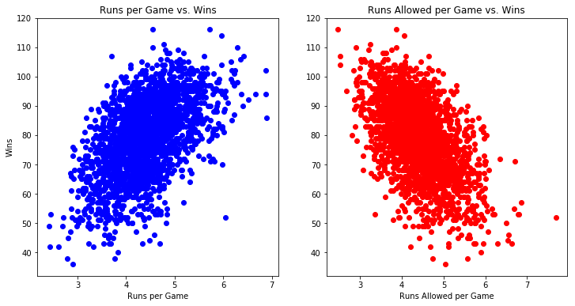

```python
# Create scatter plots for (1) runs per game vs. wins (2) runs allowed per game vs. wins
fig = plt.figure(figsize=(12, 6))
ax1 = fig.add_subplot(1,2,1)
ax2 = fig.add_subplot(1,2,2)

ax1.scatter(df['R_per_game'], df['W'], c='blue')
ax1.set_title('Runs per Game vs. Wins')
ax1.set_ylabel('Wins')
ax1.set_xlabel('Runs per Game')

ax2.scatter(df['RA_per_game'], df['W'], c='red')
ax2.set_title('Runs Allowed per Game vs. Wins')
ax2.set_xlabel('Runs Allowed per Game')

plt.show()
```

```python
df.corr()['W']
```

```
G              0.178958
W              1.000000
R              0.551504
AB             0.233996
H              0.380281
2B             0.262323
3B             0.016970
HR             0.312713
BB             0.345348
SO             0.072069
SB             0.133300
RA            -0.518313
ER            -0.372580
ERA           -0.425833
CG            -0.041788
SHO            0.426892
SV             0.382174
IPouts         0.326087
HA            -0.384893
HRA            0.009880
BBA           -0.284782
SOA            0.259205
E             -0.304725
DP             0.015192
FP             0.319597
win_bins       0.912545
era_1         -0.077104
era_2         -0.083089
era_3         -0.033073
era_4         -0.052278
era_5          0.042122
era_6          0.058439
era_7          0.066049
era_8          0.043453
mlb_rpg        0.025725
decade_1910   -0.077104
decade_1920   -0.055176
decade_1930   -0.052358
decade_1940   -0.050249
decade_1950   -0.047499
decade_1960    0.028594
decade_1970    0.033679
decade_1980    0.043516
decade_1990    0.044150
decade_2000    0.052283
decade_2010    0.043453
R_per_game     0.528489
RA_per_game   -0.550696
Name: W, dtype: float64
```

# K-means Cluster Algorithm(Add new features)

K-means is a simple clustering algorithm that partitions the data based on the number of k centroids you indicate. Each data point is assigned to a cluster based on which centroid has the lowest Euclidian distance from the data point.

- First, create a DataFrame that leaves out the target variable:
- Determine how many clusters you want with a range of numbers of clusters
  - Sklearn’s silhouette_score() function returns the mean silhouette coefficient over all samples. The silhouette score decreases as more clusters are added.
- fit_transform() method and then visualize the clusters

```python
#create a DataFrame that leaves out the target variable:
attributes = ['G','R','AB','H','2B','3B','HR','BB','SO','SB','RA','ER','ERA','CG',
'SHO','SV','IPouts','HA','HRA','BBA','SOA','E','DP','FP','era_1','era_2','era_3','era_4','era_5','era_6','era_7','era_8','decade_1910','decade_1920','decade_1930','decade_1940','decade_1950','decade_1960','decade_1970','decade_1980','decade_1990','decade_2000','decade_2010','R_per_game','RA_per_game','mlb_rpg']
data_attributes = df[attributes]

# Print the first rows of `df`
print(df.head())
```

```
  teamID    G   W    R    AB     H   2B  3B   HR   BB     ...       \
0    LAA  162  70  744  5424  1331  218  22  189  681     ...
1    LAA  162  86  718  5499  1377  232  35  137  602     ...
2    LAA  161  70  597  5506  1378  208  38   95  448     ...
3    LAA  162  82  544  5362  1297  186  27  102  472     ...
4    CAL  162  75  527  5354  1279  200  36   92  443     ...

   decade_1940  decade_1950  decade_1960  decade_1970  decade_1980  \
0            0            0            1            0            0
1            0            0            1            0            0
2            0            0            1            0            0
3            0            0            1            0            0
4            0            0            1            0            0

   decade_1990  decade_2000  decade_2010  R_per_game  RA_per_game
0            0            0            0    4.592593     4.839506
1            0            0            0    4.432099     4.358025
2            0            0            0    3.708075     4.099379
3            0            0            0    3.358025     3.401235
4            0            0            0    3.253086     3.512346

[5 rows x 49 columns]
```

## Silhouette Score

```python
# Import necessary modules from `sklearn`
from sklearn.cluster import KMeans
from sklearn import metrics

# Create silhouette score dictionary to save the results of score
s_score_dict = {}

#check the score of differnet number of clusters (from 2 to 10)
for i in range(2,11):
    km = KMeans(n_clusters=i, random_state=1)
    l = km.fit_predict(data_attributes)
    s_s = metrics.silhouette_score(data_attributes, l)
    s_score_dict[i] = [s_s]

#print the silhouette score
print(s_score_dict)
```

```
{2: [0.39069980593317305], 3: [0.33807573577084149], 4: [0.25340919058367151], 5: [0.2356155341945731], 6: [0.21388672617643892], 7: [0.19570335287377016], 8: [0.1866084436568009], 9: [0.17354531572344004], 10: [0.1698642829163392]}
```

## New Feature: Labels --- Different Clusters

- Set your number of clusters to 6 and the random state to 1.
- Determine the Euclidian distances for each data point by using the fit_transform() method
- Then visualize the clusters with a scatter plot.

```python
# Create K-means model and determine euclidian distances for each data point
kmeans_model = KMeans(n_clusters=6, random_state=1)
distances = kmeans_model.fit_transform(data_attributes)
```

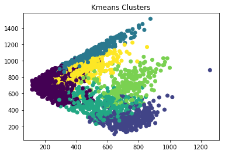

```python
# Create scatter plot using labels from K-means model as color
labels = kmeans_model.labels_
plt.scatter(distances[:,0], distances[:,1], c=labels)
plt.title('Kmeans Clusters')

plt.show()
```

**Add the labels from clusters into the data set as a new column.**

Add the string “labels” to the attributes list, for use later.

```python
# Add labels from K-means model to df DataFrame and attributes list
df['labels'] = labels
attributes.append('labels')

# Print the first rows of `df`
print(df.head())
```

```
  teamID    G   W    R    AB     H   2B  3B   HR   BB   ...    decade_1950  \
0    LAA  162  70  744  5424  1331  218  22  189  681   ...              0
1    LAA  162  86  718  5499  1377  232  35  137  602   ...              0
2    LAA  161  70  597  5506  1378  208  38   95  448   ...              0
3    LAA  162  82  544  5362  1297  186  27  102  472   ...              0
4    CAL  162  75  527  5354  1279  200  36   92  443   ...              0

   decade_1960  decade_1970  decade_1980  decade_1990  decade_2000  \
0            1            0            0            0            0
1            1            0            0            0            0
2            1            0            0            0            0
3            1            0            0            0            0
4            1            0            0            0            0

   decade_2010  R_per_game  RA_per_game  labels
0            0    4.592593     4.839506       5
1            0    4.432099     4.358025       0
2            0    3.708075     4.099379       0
3            0    3.358025     3.401235       0
4            0    3.253086     3.512346       0

[5 rows x 50 columns]
```

# Trainning Set and Test Set

Before you can build your model, you need to split your data into train and test sets. **You do this because if you do decide to train your model on the same data that you test the model, your model can easily overfit the data: the model will more memorize the data instead of learning from it, which results in excessively complex models for your data.That also explains why an overfitted model will perform very poorly when you would try to make predictions with new data.**

## New Data Set

- Create a list **numeric_cols** with all of the columns you will use in your model.
- Next, create a **new DataFrame data** from the df DataFrame with the columns in the numeric_cols list.

```python
# Create new DataFrame using only variables to be included in models
numeric_cols = ['G','R','AB','H','2B','3B','HR','BB',
                'SO','SB','RA','ER','ERA','CG','SHO','SV','IPouts',
                'HA','HRA','BBA','SOA','E','DP','FP',
                'era_1','era_2','era_3','era_4','era_5','era_6','era_7','era_8',
                'decade_1910','decade_1920','decade_1930','decade_1940','decade_1950','decade_1960','decade_1970','decade_1980','decade_1990','decade_2000','decade_2010',
                'R_per_game','RA_per_game','mlb_rpg','labels','W']

data = df[numeric_cols]
print(data.head())
```

```
     G    R    AB     H   2B  3B   HR   BB      SO   SB ...  decade_1970  \
0  162  744  5424  1331  218  22  189  681  1068.0   37 ...            0
1  162  718  5499  1377  232  35  137  602   917.0   46 ...            0
2  161  597  5506  1378  208  38   95  448   916.0   43 ...            0
3  162  544  5362  1297  186  27  102  472   920.0   49 ...            0
4  162  527  5354  1279  200  36   92  443   973.0  107 ...            0

   decade_1980  decade_1990  decade_2000  decade_2010  R_per_game  \
0            0            0            0            0    4.592593
1            0            0            0            0    4.432099
2            0            0            0            0    3.708075
3            0            0            0            0    3.358025
4            0            0            0            0    3.253086

   RA_per_game  mlb_rpg  labels   W
0     4.839506        4       5  70
1     4.358025        4       0  86
2     4.099379        3       0  70
3     3.401235        4       0  82
4     3.512346        3       0  75

[5 rows x 48 columns]
```

```python
print(numeric_cols)
print(attributes)
```

```
['G', 'R', 'AB', 'H', '2B', '3B', 'HR', 'BB', 'SO', 'SB', 'RA', 'ER', 'ERA', 'CG', 'SHO', 'SV', 'IPouts', 'HA', 'HRA', 'BBA', 'SOA', 'E', 'DP', 'FP', 'era_1', 'era_2', 'era_3', 'era_4', 'era_5', 'era_6', 'era_7', 'era_8', 'decade_1910', 'decade_1920', 'decade_1930', 'decade_1940', 'decade_1950', 'de…
['G', 'R', 'AB', 'H', '2B', '3B', 'HR', 'BB', 'SO', 'SB', 'RA', 'ER', 'ERA', 'CG', 'SHO', 'SV', 'IPouts', 'HA', 'HRA', 'BBA', 'SOA', 'E', 'DP', 'FP', 'era_1', 'era_2', 'era_3', 'era_4', 'era_5', 'era_6', 'era_7', 'era_8', 'decade_1910', 'decade_1920', 'decade_1930', 'decade_1940', 'decade_1950', 'de…
```

## Randomly Split The Data

- Then, also create your train and test data sets by **sampling** the DataFrame data. Take a random sample of 75 percent of the data for the train data set and use the other 25 percent for test data set.

```python
# Split data DataFrame into train and test sets to avoid overfitting
train = data.sample(frac=0.75, random_state=1)
test = data.loc[~data.index.isin(train.index)]

x_train = train[attributes]
y_train = train['W']
x_test = test[attributes]
y_test = test['W']
```

# Linear Regression Model

The first model you will train will be a linear regression model.

- Import **LinearRegression** and **mean_absolute_error** from **sklearn.linear_model** and **sklearn.metrics** respectively,
- Create a model lr.
- Fit the model, make predictions and determine mean absolute error of the model.

## Selecting Error Metric and Linear Regression

**Mean Absolute Error (MAE) is the metric used to determine how accurate your model is. It measures how close the predictions are to the eventual outcomes.** Provide you with the average absolute value that your prediction missed its mark.

```python
# Import `LinearRegression` from `sklearn.linear_model`
from sklearn.linear_model import LinearRegression

# Import `mean_absolute_error` from `sklearn.metrics`
from sklearn.metrics import mean_absolute_error

# Create Linear Regression model, fit model, and make predictions
lr = LinearRegression(normalize=True)
lr.fit(x_train, y_train)
predictions = lr.predict(x_test)
```

```python
# Determine mean absolute error
mae = mean_absolute_error(y_test, predictions)

print('The average number of wins is '+ str(df['W'].mean()))

# Print `mae`
print('On average, the model is off by '+ str(mae) + ' wins.')
```

```
The average number of wins is 79.2114790287
On average, the model is off by 2.68395429496 wins.
```

## Ridge regression model --- Regularzation

- Import **RidgeCV** from **sklearn.linear_model** and create model rrm.
- The RidgeCV model allows you to set the **alpha parameter**, which is a complexity parameter that controls the amount of shrinkage.
- Use **cross-validation** to deterime which of the alpha parameters you provide is ideal.

```python
# Import `RidgeCV` from `sklearn.linear_model`
from sklearn.linear_model import RidgeCV

# Create Ridge Linear Regression model, fit model, and make predictions
rrm = RidgeCV(alphas=(0.01, 0.1, 1.0, 10.0), normalize=True)
rrm.fit(x_train, y_train)
predictions_rrm = rrm.predict(x_test)

# Determine mean absolute error
mae_rrm = mean_absolute_error(y_test, predictions_rrm)
print(mae_rrm)

print('Performed slightly better and is off by ' + str(mae_rrm)+ ' wins, on average.')
```

```
2.6727655839
Performed slightly better and is off by 2.6727655839 wins, on average.
```

## Linear Regression with Numpy Array

In previous steps, we process data with pandas data frame format. Then **we transform pandas data frame format into numpy format** in order to perform other functions.

```python
y = y_train.values
X = x_train.values

yt = y_test.values
Xt = x_test.values

print("Dimensions of y before reshaping: {}".format(y.shape))

# Reshape y
y = y.reshape(-1, 1)

# Print the dimensions of X and y after reshaping
print("Dimensions of y after reshaping: {}".format(y.shape))

print("Dimensions of X: {}".format(X.shape))
```

```
Dimensions of y before reshaping: (1699,)
Dimensions of y after reshaping: (1699, 1)
Dimensions of X: (1699, 47)
```

```python
# Import LinearRegression
import numpy as np
from sklearn.linear_model import LinearRegression
from sklearn.metrics import mean_squared_error
from sklearn.model_selection import train_test_split

# Create the regressor: reg
reg = LinearRegression()

reg.fit(X, y)

y_pred = reg.predict(Xt)

# Compute and print R^2 and RMSE
print("R^2: {}".format(reg.score(Xt, yt)))
rmse = np.sqrt(mean_squared_error(yt, y_pred))
print("Root Mean Squared Error: {}".format(rmse))
```

```
R^2: 0.933137054686
Root Mean Squared Error: 3.40003934513
```

## Lasso Regression

```python
# Import Lasso
from sklearn.linear_model import Lasso

# Instantiate a lasso regressor: lasso
lasso = Lasso(alpha=0.4, normalize=True)

# Fit the regressor to the data
lasso.fit(X, y)

# Compute and print the coefficients
lasso_coef = lasso.coef_
print('It seems all ' + str(lasso_coef.shape[0])+ ' features are important in terms of target value: wins')
print( lasso_coef)
```

[output not shown]